# Linear Regression Project for grades Data

### Assumptions Test for ft3 &f23 Models

#### Check of linear relationship

```
*For ft3 let us draw  scatter pot  for final  & total and final and quiz3
*For f23 let us draw  scatter pot  for final  & quiz2 and final  and quiz3
```

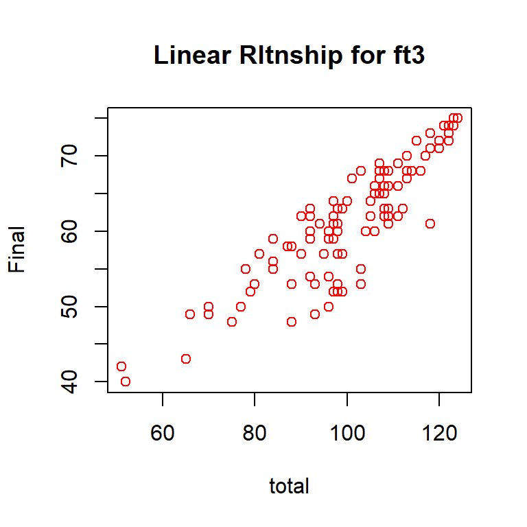

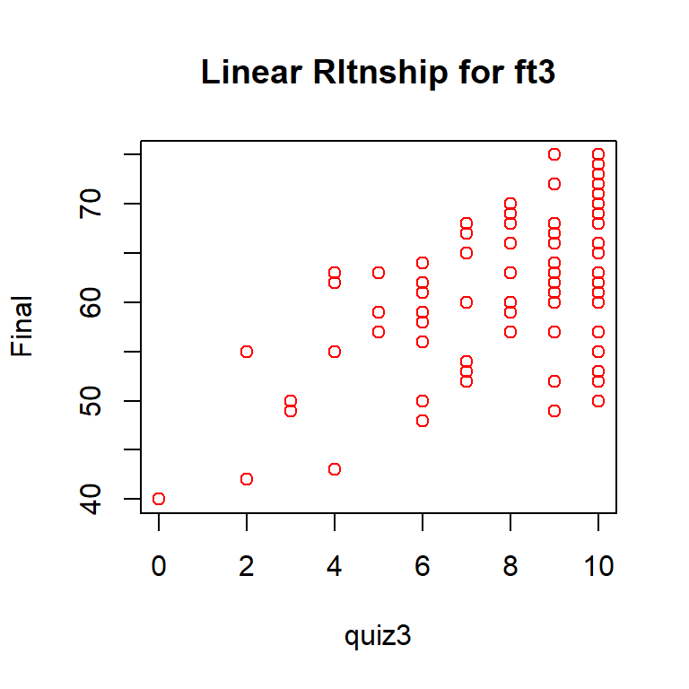

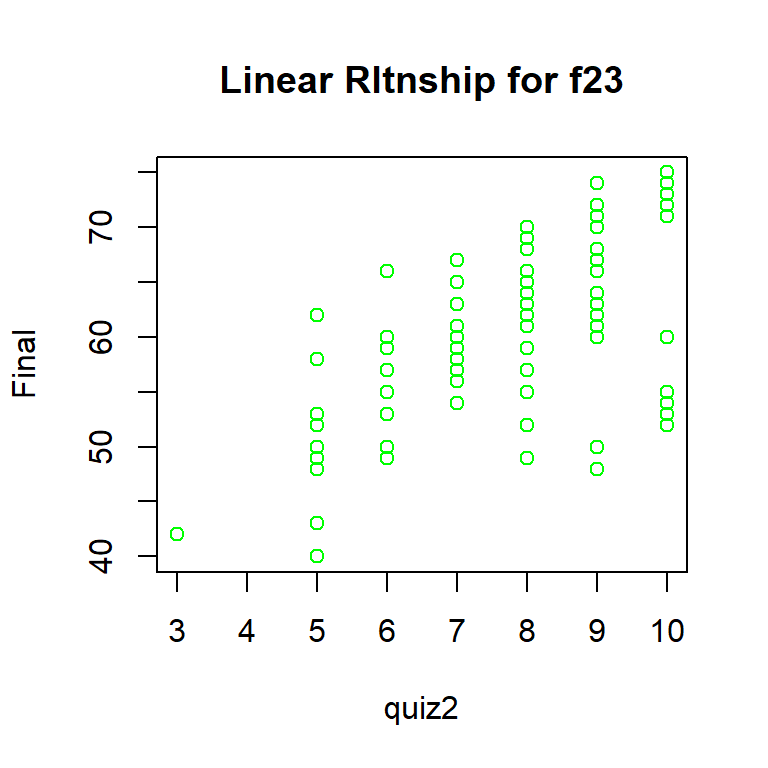

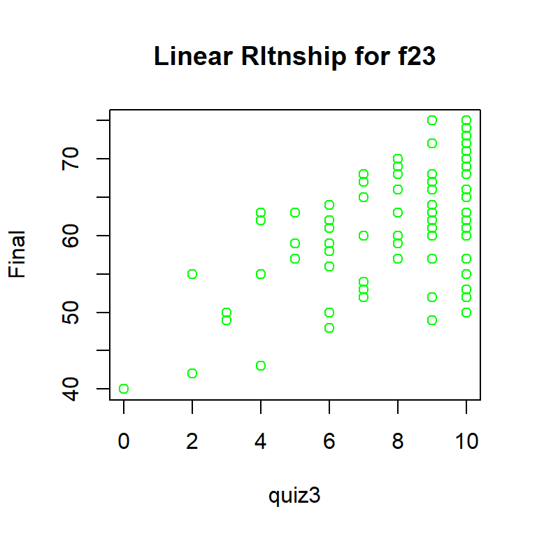

#### Question 12. Test the assumption of Constant Error Variance and interpret in maximum 3 lines

```
Answer :
```

### Assumptions Test for ft3 & f23 Models

#### Check of Constant Error Variance : Homoscedacity

```
*For ft3 let us draw  scatter pot  for residuals   & Predicted
*For f23 let us draw  scatter pot  for residuals   & Predicted
```

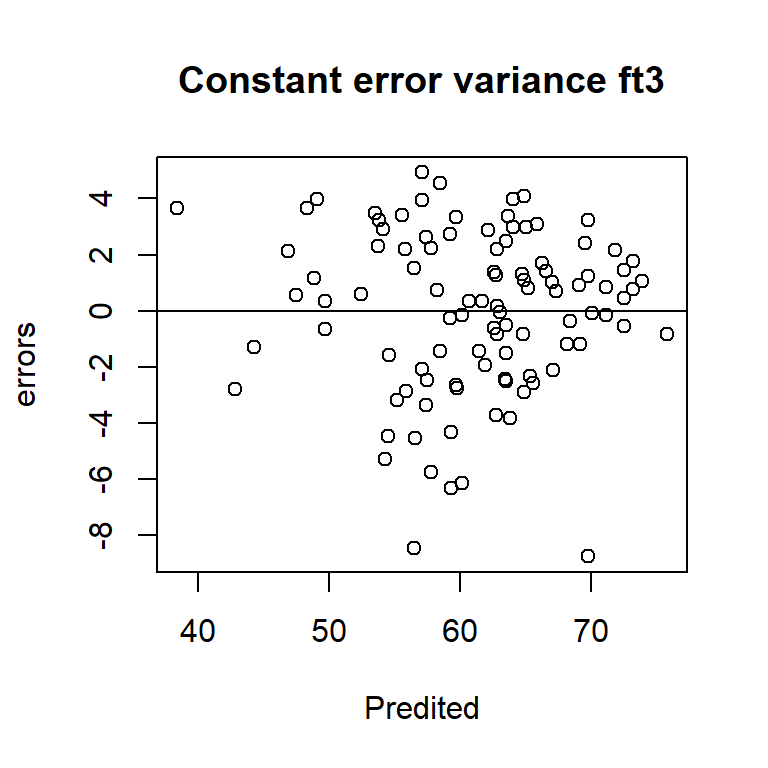

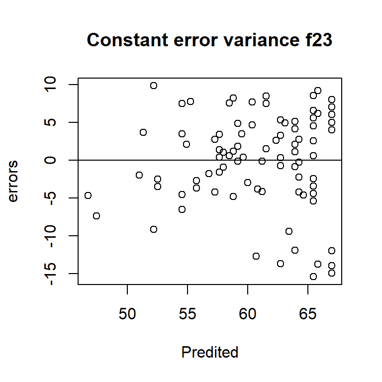

#### Question13. What is Standard Error of Estimate of your model and how do you interpret the same. Show with some hypothetical values of predictors.

```
Answer:
```

##### The standard error of estimate for our model also called Residual standard error

```
*For model ft3 standard error of estimate is  2.857 &
*For model f23 standard error of estimate  is 6.381
```

The standard error of estimate is a measure of the accuracy of predictions. In a regression line, the smaller the standard error of the estimate is, the more accurate the predictions are.

This standard error of estimate is the used to give us the confidence intervals at a particular level of confidence intervals. It is never good to give predictions in the Point estimate form so we give them in a range using standard error of estimate.

Say, you want to predict final for a given total & quiz3 marks using ft3 model equation

[output not shown]

We can also find the upper & lower range or the confidence interval using Standard error of estimate & the predicted values for ft3 model Ul of final & Ll of final

Now,Lets find predicted value using f23 model whose equation is given by

```
final =     39.7129 + (1.5407*quiz2) + (1.1862*quiz3)
Lets find for quiz2= 5 & quiz3=7
final =     39.7129 + (1.5407*5) + (1.1862*7)
final= 55.7198
```

The fitted values or the confidence intervals are given below

```
*For ft3
```

```r
confint(ft3)
```

```
##                  2.5 %     97.5 %
## (Intercept)  2.4776503 10.8695072
## total        0.6299347  0.7601126
## quiz3       -2.3230972 -1.4601374
```

```r
fitted(ft3)
```

[output not shown]

```
*For f23
```

```r
fitted(f23)
confint(f23)
predict(f23, interval="confidence")   #same as fitted
```

[output not shown]

#### Question no 14: Congratulation! You have done a marvellous job indeed and build your first predictive model. M just reminding that regression model is somewhere 50% of a data analyst routine job and has great importance in practical world.

#### Now write a summary of your findings in 250 words which you will show to your reporting manager (before forwarding the model to your client/Principal in this case). This time, no R Output and minimum pictures are needed. Mind it, your reporting manager is a senior statistician/data scientist and do not have time to go into your entire work. He will prefer to read meaningful, to the point and technically correct summary! Here is your chance to impress your boss!

```
Answer :
```

Grades.csv consists of 105 observations and 22 variables (mostly categorical or nominal ) .The data tells about the details of the students giving gender, ethnicity, class sections ,marks in 5 quizzes ,marks in final, total marks, gpa and percentage and also tell whether the student is pass or fail .

As we the main motive of the project was to to build a predictive model for predicting final for consumption I have built two linear regression models to predict final .

```
#####Model to predict final using quiz2 & quiz3
```

One of our Linear Regression Model predicts the final score using the performance in quiz2 & quiz3 combined. The name of this model is f23 This multiple regression model helps us explain the variance in the final with 36.71% confidence and the remaining 63.29% is due to the other factors like quiz1 quiz2 quiz3 quiz4 quiz5 gpa or total etc. The model predictors have significant slope with the dependent or the response variable final which is checked by the significance value for t-test of the predictors i.e the p-value. Moreover the Variance Inflation factor for both the variables is 1.89 which is in acceptance zone meaning these two predictors are not highly correlated .Also the DWS for the model is 2.233 which lies in the no autocorrelation zone meaning our linear regression is a right model for predicting . Standard error of estimate of our model is 6.381 means that with this much standard deviation range we would be able to predict our final range with 95% confidence level. The equation of the model of predicting final using quiz2 & quiz3 with 36.71% variance in final explained is given as below:

```
final=39.7129 + (1.5407×quiz2)+ (1.1862×quiz3)
```

The f-test significance value i.e p-value of -f-test is less than LOS meaning that the test of overall model is significant with the final dependent variable. The assumptions of our models like normality, Linear relationship ,constant error variance are almost satisfied with the data provided and calculated .so we can say that our Model I right way to predict final using quiz2 & quiz3 scores

```
#####Model for predicting final using the variables total and quiz 3
```

The name of the model is ft3. This multiple regression model helps us explain the variance in the final with 87.31% confidence and the remaining 12.69% is due to the other factors like quiz1 quiz2 quiz3 quiz4 quiz5 gpa alone or grouped together. The model predictors have significant slope with the dependent or the response variable final which is checked by the significance value for t-test of the predictors i.e the p-value of t test for model. p-value for t-test is 2e-16 and for quiz3 it is 6.192-14. The equation for the model ft3 is given by :

```
final =6.67358 + (.69502×total) - (1.89612×quiz3)
```

#### Question No 15 : This is final stroke! Besides your boss, your client is equally or rather more important to you! Your challenge is this that the Principal/client is not statistics savvy! You need to summarize your work/findings in a non statistical manner or in a lay man manner and this is indeed challenging. However, no way out and you have to do it in a simple but impressive manner (impressive to client!). Write down summary in 500 words.

```
Answer:
```

```
 final =6.67358 + (.69502×total) - (1.89612×quiz3)
```

final=39.7129 + (1.5407×quiz2) + (1.1862×quiz3)

```
final =6.67358 + (.69502×100) - (1.89612×9)
```

Similarly a second model name f23 which predicts the final score using the quiz2 & quiz3 score will predict final score for quiz2=8 and quiz3=9 ,equals to 62.7143 with a 36.71% variance in final which is explained using these two predictors

```
final=39.7129 + (1.5407×8) + (1.1862×9)
```

As we can understand these predicted final values are point estimates ,so we need to find out the range/intervals of final that will help us predict the scores to a better extent keeping some deviations in mind .These are called confidence intervals. They are calculated using the standard error of estimate. For our model which uses total and quiz3 for predicting final sore has a standard error of estimate as 2.857 & the model which uses quiz2 and quiz3 for predicting final sore has a standard error of estimate as 6.381

For example: If we want to predict a confidence interval for a predicted score of 59.11 which is obtained using a we will use the formula for model named ft3

[output not shown]

Similarly If we want to predict a confidence interval for a predicted score of 62.7143 which is obtained using quiz2 & quiz3 scores we will use the below formula for model named f23

[output not shown]

This is as simple explanations to predict the final scores based on the best models which can be built using predictor variables available. The Model named ft3 which uses total as a predictor can help us predict final only if either total score is available with or total sore is assumed and based on it the final score obtained by model can be predicted.